SET 8 · MONTE CARLO DISPATCH RISK

# The distribution is the risk

Pascual Zárate · research with Adrian DeClerq · University of Chicago  
Julia · JuMP · HiGHS · 10,000 scenarios per model

The distribution is the risk

**Opening**Set the frame in one line: this is not a study of your grid, it is a study of how grid studies go wrong. The number on the next slide is the hook — let it sit before explaining it.

The finding

## Same network. Same code. Same solver.

19.77%

of hours require cutting customers off  
**— assuming** an exponential demand distribution

the only  
difference

0.00%

of hours require cutting customers off  
**— using** 8,760 filed hours of real load

Neither run contains an arithmetic error. We verified both exhaustively. The *only* thing that changed was the probability distribution the demand was drawn from.

The distribution is the risk

**The hook**Pause here. Let them read both numbers. Then: "If a consultant handed you either of these, nothing on the page would tell you which one you were getting." Do not explain the mechanism yet — that is Act II.

Before anything else

## What this is, and what it is not

What it is

A **methodological** result about how risk estimates respond to distributional assumptions. Demonstrated on a 9-bus representation of Oʻahu and on the standard IEEE-14 test network.

What it is not

A study of your system. Our topology is a **sketch** we constructed; our line ratings are assumed. No contingency analysis, no forced outages, no reserves, no unit commitment, no storage.

So we are deliberately not quoting you a reserve margin

Our model produces one. We are leaving it out, because a sparse 9-bus sketch has far fewer delivery paths than a real meshed network — which biases that number **pessimistically** by an amount we cannot size. Presenting it would be exactly the error this talk is about.

The distribution is the risk

**Credibility slide — do not rush it**Putting the limits up front, before any result, is what earns the right to the rest. If asked about the reserve margin number: it exists, we can share the methodology, but the topology it rests on is not good enough to quote to this room. That answer is the point of the talk.

The experiment

## Hold the grid completely fixed. Re-roll only demand.

**Fixed:** topology, generator capacities, marginal costs, line ratings, reference bus. Nothing about the network moves between scenarios.

**Rolled:** the demand at every node, redrawn 10,000 times.

Then read the answer as a **distribution**, not a number.

Three questions per run

- How often does the **most expensive** generator have to run?
- How often must we **cut customers off**?
- How often is a **line at its limit**?

The distribution is the risk

**Method, part 1**Emphasise the control: because the network never changes, any difference between runs is attributable to the demand model alone. That is what makes the comparison clean.

The experiment

## We never let the solver say “infeasible”

A dispatch model that cannot serve demand normally returns an error. An error is one bit of information: yes or no. We wanted megawatts.

What we did

Added **load shedding as a priced decision**, at a value of lost load of $10,000/MWh. The model may always refuse an order — it simply pays dearly for it.

Why it matters to you

Every scenario now returns an answer, and “infeasible” becomes a measurable quantity: **how many megawatts short, and where**. Shortfall becomes something you can rank, budget against and compare.

The distribution is the risk

**Method, part 2**This is the one modelling choice worth defending in detail. It is standard in the literature but often skipped in practice, and it is why we can report a distribution of shortfall instead of a pass/fail count.

The assumption under test

## The demand model we were told to use

Draw each node's demand from an exponential distribution scaled to its average. It is a common default: analytically convenient, widely used, and it requires only a mean.

What that quietly asserts

That a neighbourhood's **most likely demand is zero**, and that its tail runs past four times its own average. Its coefficient of variation is exactly 1.

Nobody writes that down

It arrives as a line of code, not as a claim about the island. That is what makes it dangerous: it is an assumption that never has to be defended, because it is never stated.

The distribution is the risk

**Set up the villain**Be fair to the assumption: it is not stupid, it is convenient and it is standard when you have nothing but a mean. The problem is that on Oahu we DO have more than a mean.

Reality check

## Against 8,760 hours of what the island actually did

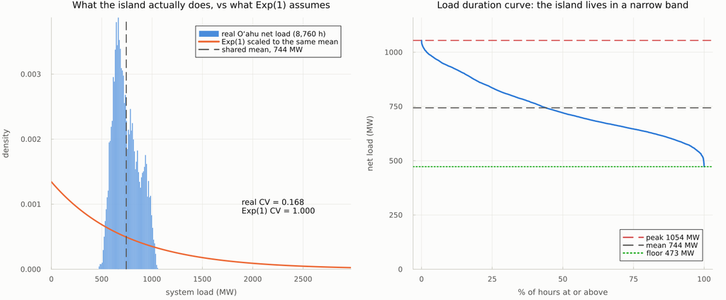

Both curves carry the **identical mean of 744 MW**, so the only thing being compared is shape. The real island never leaves a band of roughly 0.64 to 1.42 times its own average — floor 473 MW, peak 1,054 MW.

The distribution is the risk

**The evidence**This is the slide that makes the rest inevitable. Same mean, completely different shape. Point at the right-hand panel: the load duration curve is flat and bounded, which is what a real island looks like and what an exponential can never look like.

Reality check

## One number captures the gap

Coefficient of variation — spread divided by average. Unitless, so it compares anything to anything.

| Measured on | CV | Reading |
| --- | --- | --- |
| One node, assumed model | 1.00 | as spread as a positive quantity gets |
| Island total, assumed model | 0.53 | adding eight nodes cancels some of it |
| Island total, real filed record | 0.17 | three times calmer still |

The consequence

Under the assumed model the island exceeds twice its average demand about **one hour in nineteen**. In 8,760 recorded hours the real island did it **zero times** — its busiest hour ever does not reach 1.5× average.

The distribution is the risk

**Quantify it**The 1.00 / 0.53 / 0.17 ladder is worth saying out loud. Aggregation across nodes does some of the calming, but not nearly enough — even after aggregating, the assumption is three times wilder than reality.

ACT II

## What changed when we swapped the assumption

The distribution is the risk

**Transition**Everything so far was setup. From here, the results. Signal clearly that the next three slides are the core of the talk.

Results · Oʻahu, 10,000 scenarios each

## The two failure modes moved in opposite directions

|  | Assumed Exp(1) | Real filed hours | Change |
| --- | --- | --- | --- |
| Customers cut off | 19.77% | 0.00% | collapsed to zero |
| Costliest generator runs | 5.48% | 0.00% | collapsed to zero |
| **A line at its limit** | 58.40% | 92.51% | rose 34 points |

This is the part that should worry a planner

A wrong demand assumption did not make the grid look uniformly safer or uniformly scarier. It **relocated** the risk — hiding a congestion problem behind an adequacy problem that does not exist.

The distribution is the risk

**Core result**The instinct in the room will be "so the assumption was conservative, fine." Kill that instinct here. Conservative would mean uniformly worse. This is not conservative — one number went to zero while another went up 34 points.

Results

## The whole study in one chart

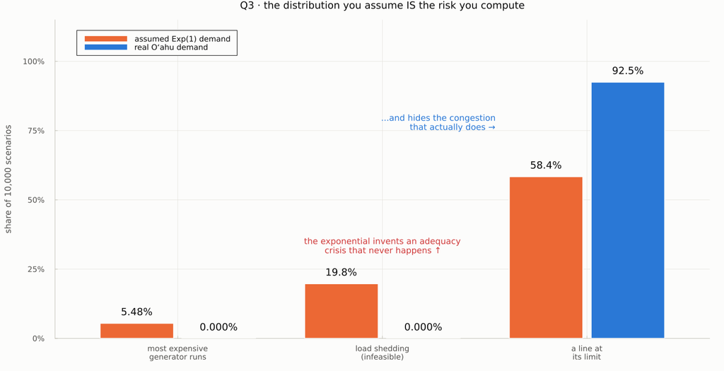

Orange is the assumed exponential demand. Blue is the real filed record. Left and centre: the exponential invents an adequacy crisis that never happens. Right: it hides the congestion that actually does.

The distribution is the risk

**The picture**If you only have time for one slide, it is this one. Two bars go to zero, one bar goes up sharply. Opposite directions.

ACT III

## Why the two risks behave differently

The distribution is the risk

**Transition**Now the mechanism. The next two slides are the intellectual contribution: congestion and adequacy are different KINDS of quantity, and that is why one assumption moves them in opposite directions.

Mechanism

## Two questions, two different geometries

Congestion asks “how much”

Whether a line fills up depends almost entirely on the **island total** — and hardly at all on which neighbourhoods are asking.

**One threshold governs it.**

Adequacy asks “where”

Whether the island can physically serve demand depends heavily on the **mix of neighbourhoods**. Turn the same total toward a different set of places and the answer changes completely.

**It has a different limit in every direction.**

Why that produces opposite movement

The assumed model gets the *total* wrong — it spends far too much time idling low — so it understates congestion. It also aims in *random directions*, and most directions are worse than the one real demand actually takes — so it overstates blackouts.

The distribution is the risk

**The idea**Say it plainly: congestion is about magnitude, adequacy is about direction. We initially conjectured the opposite for congestion and our own data refuted us — worth admitting out loud, it plays well and it is true.

Mechanism · the strongest evidence

## One number predicts congestion under both models

585

**megawatts.** A single island-wide total threshold, fitted once. Above it, a line is at its limit; below it, none is.

| Congestion frequency | From 585 MW alone | Actually observed | Gap |
| --- | --- | --- | --- |
| Assumed Exp(1) | 59.0% | 58.40% | 0.6 pp |
| Real filed hours | 92.2% | 92.51% | 0.3 pp |

Two demand distributions with nothing in common, and one scalar reproduces both congestion rates to under a percentage point. The reason the rates differ is simply that the assumed model idles below 585 MW **41% of the time**, while the real island does so in only **7.8%** of its 8,760 hours.

The distribution is the risk

**Spend time here**This is the most defensible technical claim in the deck. Two radically different distributions, one scalar, sub-percentage-point accuracy on both. It also means congestion risk can be screened cheaply without running the full model — which is a practical takeaway, not just an academic one.

Mechanism

## Why the blackout risk was imaginary

For adequacy there is no single threshold. There is a different limit for every possible mix of neighbourhoods. We measured that limit across many mixes:

| Serving limit, by mix of neighbourhoods | MW |  |
| --- | --- | --- |
| Worst mix found | 409 | the grid gives out early |
| Median mix | 1,028 |  |
| Best mix found | 1,496 |  |
| **The mix real demand actually takes** | 1,082 | better than 65% of mixes |

Real demand does not wander. It takes **one habitual shape**, day after day, and that shape happens to be a comparatively favourable one. A model that aims randomly finds trouble that the island, on its actual daily pattern, never meets.

The distribution is the risk

**The counterpart**Important caveat if pressed: "lucky" is measured on OUR topology. The mechanism — that real demand occupies one narrow region of the space while the assumption explores all of it — is general and does not depend on our network being right.

A third example

## The same trap, on the supply side

Adding up what generators are *rated* to produce is not the same as what the network can *deliver* to where people are. On our model the gap is 28%.

Why we raise it

Because it is the same error in a different costume: a headline number whose assumptions are buried. A reserve margin computed against nameplate and one computed against deliverable capacity are **not the same statistic**.

Why we are not giving you our number

The gap depends entirely on topology and line ratings — exactly what our 9-bus sketch gets least right, and in a direction that makes things look **worse** than they are. Our figure would be precise and wrong.

The transferable point: **ask what capacity figure a reserve margin was computed against**, and whether the delivery network was in the calculation at all.

The distribution is the risk

**Restraint as credibility**Declining to give a number you have is a strong move in this room. If someone pushes, offer the methodology and the code, not the figure. That is the honest position and it reads as confidence rather than evasion.

The takeaway

## What to ask of any grid study on your desk

| Question | Why it decides the headline number |
| --- | --- |
| **What distribution was demand drawn from, and why that one?** | It sets the answer. Ours moved shedding from 19.77% to zero. |
| **Was it fitted to filed load data, or assumed?** | A mean is not a distribution. Shape is where the risk lives. |
| **Does the study report congestion and adequacy separately?** | They respond to assumptions in opposite directions. One aggregate number hides that. |
| **What capacity was the reserve margin computed against?** | Nameplate and deliverable are different statistics. |

None of these require re-running anyone's model. They are answerable from the methodology section — and they are the questions that determine whether the headline figure means anything.

The distribution is the risk

**The practical payoff**This is what the audience actually takes home. Four questions they can put to any consultant, answerable without technical staff. Slow down and let them write these down.

ACT IV

## What it would take to make this decision-grade

The distribution is the risk

**Transition**They asked for this section implicitly by being in the room. Frame it as: here is the honest distance between a research model and something you could act on.

Roadmap · tier one

## These change the answer qualitatively

| Missing constraint | Why it dominates on an island grid |
| --- | --- |
| 1Forced outage rates | Adequacy studies are largely *about units failing*. We assume every generator is always available. |
| 2N−1 security | Oʻahu has no neighbours to import from. Surviving the loss of the largest unit *is* the planning constraint. |
| 3Operating reserves | We let every unit run flat out with zero headroom. No operator would dispatch that. |
| 4Minimum stable generation and unit commitment | With roughly half of Oʻahu's single-family homes on rooftop solar, midday over-generation often binds before peak does. |
| 5Inertia and frequency response | A small isolated system has nothing to lean on when a unit trips. |

The distribution is the risk

**Honest gap analysis**Do not apologise through this slide — presenting it confidently shows you know what a production model contains. Point 4 is the one that will get nods: on a high-DER island the binding hour is often midday, not evening peak.

Roadmap · tier two, and the structural catch

## These change magnitudes — and one changes the whole design

| 6Ramp rates | on *net* load, whose evening ramp is far steeper than gross |
| --- | --- |
| 7Storage state of charge | inherently carries energy between hours |
| 8AC power flow | voltage, reactive power, and losses — typically 5–8% |
| 9Stochastic renewable supply | on a high-solar island this now exceeds demand uncertainty |

The structural catch

Every item on both tiers needs **chronological time**. Outages persist. Batteries carry charge. Ramps connect one hour to the next.

Our design samples hours *independently*. Adding these is not bolting on constraints — it is rebuilding the study as a time-series simulation.

One measurement that shows why it matters

Real Oʻahu load moves an average of **41.9 MW** hour to hour, and never more than 138. Chain the assumed model's draws together and the average swing is **424 MW** — ten times larger. Ramping would have been a *third* place where the two models diverge.

The distribution is the risk

**Tier two**Point 9 is worth saying explicitly: on Oahu today the bigger uncertainty is the supply side, not demand. Our paper randomises demand and treats supply as firm, which is backwards for this island in 2026. Say so — they will already know it, and naming it first is better than being told.

In closing

## The assumption you cannot see is the one setting the number.

What we showed

One line of code — the demand distribution — moved estimated shedding from **19.77% to zero** while moving congestion from **58.4% to 92.5%**. Same grid, same solver, no error.

What it means for reading studies

Misspecification does not simply inflate risk. It **relocates** it — which means a study can be conservative and dangerously misleading at the same time.

Full method, code and verification: Set 8 — 10,000 scenarios per model, four independent seeds, DC-OPF in Julia via JuMP and HiGHS, real load from 8,760 filed hours.

The distribution is the risk

**Close**End on the single sentence at the top. Then stop talking — do not re-summarise. Offer the code and the written paper for anyone who wants to audit it.